# Introduction to bridging Olink® NPX datasets

Compiled: October 09, 2026

Individual Olink® NPX datasets are normalized using either plate control normalization or intensity normalization methods. Plate control normalization is generally used for single plate projects or for Explore HT projects, while intensity normalization is generally used for multi-plate projects. Additionally, intensity normalization method assumes that all samples within a project are fully randomized.

In the case where all samples within a project are not fully randomized, or when a study is separated into separate batches, an additional normalization step is needed to allow the data to be comparable, since NPX is a relative measurement. The joint analysis of two or more Olink® NPX datasets often requires an additional batch correction step to remove technical variations, which is referred to as overlapping sample reference normalization, bridge normalization, or simply bridging.

Batches are groups of samples run at different times. They may or may not use the same lot of reagents, however bridging is recommended because good randomization across these sample batches is unlikely.

Bridging is also needed if Olink® NPX datasets are:

- plate control normalized only and run conditions (e.g lab and reagent lots) have changes.
- intensity normalized but from two different sample populations.

To bridge two or more Olink® NPX datasets, bridge samples are needed to calculate the assay-specific adjustment factors between datasets. Bridging samples are shared samples among datasets - that is that samples that are analyzed in both datasets. The recommended number of bridge samples are shown in the table below. Olink® NPX datasets without shared samples should not be combined using the bridging approach described below.

Table 1. Recommended number of bridge samples for Olink products.

| Olink Product | Number of Bridge Samples |
| --- | --- |
| Target 96 | 8-16 |
| Explore 384: Cardiometabolic, Inflammation, Neurology, and Oncology | 8-16 |
| Explore 384: Cardiometabolic II, Inflammation II, Neurology II, and Oncology II | 16-24 |
| Explore 3072 | 16-24 |
| Explore HT | 16-32 |
| Reveal | 16-24 |
| Explore 3072 to Explore HT | 40-64 |
| Explore 3072 to Reveal | 32-48 |

The following tutorial is designed to provide an overview of the data combining methods that are possible using the Olink® bridging process. Before starting bridging, it is important to check if the same sample IDs were assigned to the bridge samples in both datasets.

## Selecting bridge samples

Prior to running the second study, bridge samples must be selected from the reference study and added to the second study. These samples can be selected using the `olink_bridge_selector()` function in Olink Analyze. The bridge selection function will select a number of bridge samples based on the reference data. This function selects samples that pass QC and have high detectability. In the cases where detectability cannot be calculated from the test data set (ex: Explore HT data), the function will only select samples which pass QC. External controls are not selected as bridge samples as they are not representative of the study and therefore may not cover the dynamic range of assays that would be expressed within the samples. Note that due to naming convention differences, it is necessary to exclude the control samples automatically using the function `clean_npx()`, or manually using the function `stringr::str_detect()`.

To select samples across the range of the data, the samples are ordered by mean NPX value and selected across this range. When running the selector, the `sampleMissingFreq` value represents the maximum percentage of data below LOD allowed per sample. When running plasma on smaller panels, such as Target 96, `sampleMissingFreq = 0.10` can be a good starting point. Larger panels such as Explore HT have many proteins that are only expressed in certain diseases or matrices and therefore more data below LOD is expected. In this case `sampleMissingFreq = 0.5` can be a good starting point. Note that these values may need to be adjusted based on the Olink product, sample matrix, and biological context of the samples, for example, specific disease types. `sampleMissingFreq = 1` will provide a list of all eligible samples, regardless of the % of data below LOD and the function output provides the percent of assays below LOD (`PercAssaysBelowLOD`) which can help inform a good starting point for a specific study.

In this example we will demonstrate how to select 16 bridge samples using the example data set `npx_data1`. First, we will check the NPX file using the function `check_npx()` and pre-process it using the function `clean_npx()` to investigate for potential issues with the data and ensure it is in the correct format. The check log list generated from the `check_npx()` function is used to inform the cleaning process, and then the cleaned data can be re-checked to confirm that the cleaning process has resolved all issues. This process is shown in the example code below.

```r
# Load example dataset (npx_data1)
npx_data1 <- OlinkAnalyze::npx_data1

# NPX file preprocessing
# Generate check log
check_log_npx_data1 <- OlinkAnalyze::check_npx(
  df = npx_data1
)

# Clean NPX
npx_data1_clean <- OlinkAnalyze::clean_npx(
  df = npx_data1,
  check_log = check_log_npx_data1
)

# Generate check log on cleaned data
check_log_npx_data1_clean <- OlinkAnalyze::check_npx(
  df = npx_data1_clean
)
```

The following code illustrates how to select the 16 bridge samples from the cleaned reference data. The selected bridge samples are displayed in Table 2.

```r
# Using the already cleaned data from `clean_npx()`
bridge_samples <- OlinkAnalyze::olink_bridge_selector(
  df = npx_data1_clean,
  sample_missing_freq = 0.1,
  n = 16L,
  check_log = check_log_npx_data1_clean
)

# Excluding control samples manually. Naming convention may differ.
bridge_samples_manual <- npx_data1 |>
  dplyr::filter(
    stringr::str_detect(
      string = .data[["SampleID"]],
      pattern = "CONTROL",
      negate = TRUE
    )
  ) |>
  # In this case we skip the argument `check_log`. When `check_log` is not
  # provided, the function will run it internally to check for other
  # inconsistencies in the data such as duplicate sample IDs.
  OlinkAnalyze::olink_bridge_selector(
    sample_missing_freq = 0.1,
    n = 16L
  )
```

Table 2. Selected bridge samples.

| SampleID | PercAssaysBelowLOD | MeanNPX |
| --- | --- | --- |
| B13 | 0.05 | 6.32 |
| B65 | 0.05 | 6.39 |
| A20 | 0.05 | 6.54 |
| A53 | 0.04 | 6.28 |
| B35 | 0.07 | 6.24 |
| B34 | 0.05 | 5.87 |
| B20 | 0.06 | 6.46 |
| B36 | 0.07 | 6.20 |
| A47 | 0.07 | 6.15 |
| B55 | 0.08 | 6.26 |
| B9 | 0.06 | 5.99 |
| B79 | 0.06 | 6.11 |
| B62 | 0.05 | 6.08 |
| A77 | 0.07 | 6.22 |
| A67 | 0.04 | 6.35 |
| A59 | 0.03 | 6.07 |

It is important to confirm that the selected bridge samples are representative of the overall samples within the study. This can be assessed visually with a PCA plot generated using the code below, where the bridge samples should be evenly dispersed among the other samples (Figure 1).

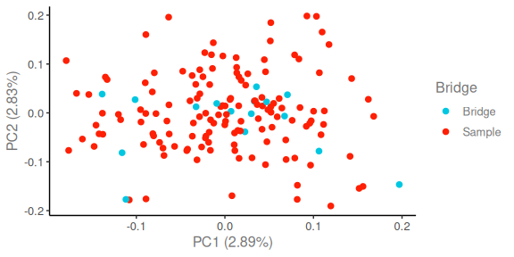

Figure 1. PCA plot of bridge samples and other samples in dataset `npx_data1` (control samples excluded).

```r
npx_data1_clean |>
  dplyr::mutate(
    Bridge = dplyr::if_else(
      .data[["SampleID"]] %in% bridge_samples[["SampleID"]],
      "Bridge",
      "Sample"
    )
  ) |>
  OlinkAnalyze::olink_pca_plot(
    color_g = "Bridge",
    check_log = check_log_npx_data1_clean
  )
```

## Setup bridging datasets

Bridging datasets are standard Olink® NPX tables. They can be loaded using the `read_NPX()` function with default Olink Software NPX files as input.

```r
npx_data1 <- OlinkAnalyze::read_NPX(
  filename = "~/NPX_file1_location.xlsx"
)
npx_data2 <- OlinkAnalyze::read_NPX(
  filename = "~/NPX_file2_location.xlsx"
)
```

## Check bridging datasets

To demonstrate how bridging works, we will use the example datasets (`npx_data1` and `npx_data2`) from the **Olink Analyze** package. This workflow also uses functions from the R packages `dplyr`, `stringr`, and `ggplot2`. The example datasets contain control samples with duplicated `SampleIDs` across datasets. Because downstream functions do not allow duplicates we will rename the control samples to have unique SampleIDs by appending a unique suffix to the control sample IDs in each dataset. This process is shown in the code below.

```r
# Load example dataset (npx_data1)
npx_data1 <- npx_data1 |>
  # create unique extension as suffix for control samples
  dplyr::mutate(
    sid_ext = stringr::str_remove(
      string = .data[["PlateID"]],
      pattern = ".csv"
    ),
    sid_ext = paste0(
      stringr::str_split_i(.data[["sid_ext"]], "_", 4L),
      stringr::str_split_i(.data[["sid_ext"]], "_", 3L)
    ),
  ) |>
  # rename SampleIDs for control samples
  dplyr::mutate(
    SampleID = dplyr::if_else(
      stringr::str_detect(
        string = .data[["SampleID"]],
        pattern = "CONTROL"
      ),
      paste0(.data[["SampleID"]], "_", .data[["sid_ext"]]),
      .data[["SampleID"]]
    )
  ) |>
  dplyr::select(
    -dplyr::all_of("sid_ext")
  )

# Load example dataset (npx_data2)
npx_data2 <- OlinkAnalyze::npx_data2 |>
  # create unique extension as suffix for control samples
  dplyr::mutate(
    sid_ext = stringr::str_remove(
      string = .data[["PlateID"]],
      pattern = ".csv"
    ),
    sid_ext = paste0(
      stringr::str_split_i(.data[["sid_ext"]], "_", 5L),
      stringr::str_split_i(.data[["sid_ext"]], "_", 4L)
    ),
  ) |>
  # rename SampleIDs for control samples
  dplyr::mutate(
    SampleID = dplyr::if_else(
      stringr::str_detect(
        string = .data[["SampleID"]],
        pattern = "CONTROL"
      ),
      paste0(.data[["SampleID"]], "_", .data[["sid_ext"]]),
      .data[["SampleID"]]
    )
  ) |>
  dplyr::select(
    -dplyr::all_of("sid_ext")
  )
```

Further, we will preprocess the NPX files using the functions `check_npx()` and `clean_npx()` as shown earlier.

```r
# NPX file preprocessing - npx_data1
# Generate check log
check_log_npx_data1 <- OlinkAnalyze::check_npx(
  df = npx_data1
)

# Clean NPX
npx_data1_clean <- OlinkAnalyze::clean_npx(
  df = npx_data1,
  # Retain control samples and assays
  remove_control_assay = FALSE,
  remove_control_sample = FALSE,
  # Retain assay and QC warnings
  remove_assay_warning = FALSE,
  remove_qc_warning = FALSE,
  check_log = check_log_npx_data1
)

# Generate check log on cleaned data
check_log_npx_data1_clean <- OlinkAnalyze::check_npx(
  df = npx_data1_clean
)

# cleanup intermediate variables
rm(
  npx_data1,
  check_log_npx_data1
)

# NPX file preprocessing - npx_data2
# Generate check log
check_log_npx_data2 <- OlinkAnalyze::check_npx(
  df = npx_data2
)

# Clean NPX
npx_data2_clean <- OlinkAnalyze::clean_npx(
  df = npx_data2,
  # Retain control samples and assays
  remove_control_assay = FALSE,
  remove_control_sample = FALSE,
  # Retain assay and QC warnings
  remove_assay_warning = FALSE,
  remove_qc_warning = FALSE,
  check_log = check_log_npx_data2
)

# Generate check log on cleaned data
check_log_npx_data2_clean <- OlinkAnalyze::check_npx(
  df = npx_data2_clean
)

# cleanup intermediate variables
rm(
  npx_data2,
  check_log_npx_data2
)
```

Identify overlapping sample IDs between studies. Often, the same sample IDs are used as bridge samples in both NPX data sets, as shown in Table 3. Note that while external controls may share identifiers between datasets, theses samples are not bridge samples. External control samples often share the same naming convention across datasets but may represent different samples due to reagent batch differences. Additionally, external control samples are unlikely to cover the dynamic range of assays expressed in the study samples.

```r
overlapping_samples <- dplyr::tibble(
  SampleID = intersect(
    x = npx_data1_clean[["SampleID"]],
    y = npx_data2_clean[["SampleID"]]
  )
) |>
  dplyr::filter(
    stringr::str_detect(
      string = .data[["SampleID"]],
      pattern = "CONTROL",
      negate = TRUE
    )
  ) |>
  dplyr::pull(
    .data[["SampleID"]]
  )
```

Table 3. Overlapping Bridge Samples.

| SampleID |
| --- |
| A13 |
| A29 |
| A30 |
| A36 |
| A45 |
| A46 |
| A52 |
| A63 |
| A71 |
| A73 |
| B3 |
| B4 |
| B37 |
| B45 |
| B63 |
| B75 |

Then, gain an overview of the datasets that are going to be bridged. For example, plot and compare NPX distribution between datasets, as shown in Figure 2. By having a sense of how the studies compared to each other before bridging, we can then determine the success of the bridging process post bridging. Figure 2 shows a large overlap between `npx_data1` and `npx_data2`, however there are still some differences as indicated by the blue and red areas on the edge of the distribution.

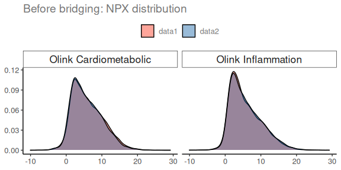

Figure 2. Density plot of NPX distribution in both datasets before bridging.

```r
# Expand the datasets to contain the Project column
npx_1 <- npx_data1_clean |>
  dplyr::mutate(
    Project = "data1"
  )
npx_2 <- npx_data2_clean |>
  dplyr::mutate(
    Project = "data2"
  )

# Combine the two data sets for visualization
npx_df <- dplyr::bind_rows(
  npx_1,
  npx_2
)

# Filter out control samples to avoid skewing the distribution
# and affecting downstream PCA results.
npx_df_no_ctrl <- npx_df |>
  dplyr::filter(
    stringr::str_detect(
      string = .data[["SampleID"]],
      pattern = "CONTROL_SAMPLE",
      negate = TRUE
    )
  ) |>
  # Mark bridge samples
  dplyr::mutate(
    Type = dplyr::if_else(
      .data[["SampleID"]] %in% .env[["overlapping_samples"]],
      paste(Project, "Bridge"),
      paste(Project, "Sample")
      )
    ) |>
  # Ensure that SampleIDs are unique across projects for downstream functions.
  dplyr::mutate(
    SampleID = paste0(.data[["SampleID"]],
                      .data[["Project"]])
  )

# Generate check log
check_log_npx_df_no_ctrl <- OlinkAnalyze::check_npx(
  df = npx_df_no_ctrl
  )

# Plot NPX density before bridging
npx_df_no_ctrl |>
  ggplot2::ggplot(
    mapping = ggplot2::aes(
      x = .data[["NPX"]],
      fill = .data[["Project"]]
    )
  ) +
  ggplot2::geom_density(
    alpha = 0.4
  ) +
  ggplot2::facet_grid(
    cols = ggplot2::vars(.data[["Panel"]])
  ) +
  OlinkAnalyze::olink_fill_discrete(
    coloroption = c("red", "darkblue")
  ) +
  OlinkAnalyze::set_plot_theme() +
  ggplot2::ggtitle(
    label = "Before bridging: NPX distribution"
  ) +
  ggplot2::theme(
    axis.title.x = ggplot2::element_blank(),
    axis.title.y = ggplot2::element_blank(),
    strip.text = ggplot2::element_text(size = 16L),
    legend.title = ggplot2::element_blank(),
    legend.position = "top"
  )
```

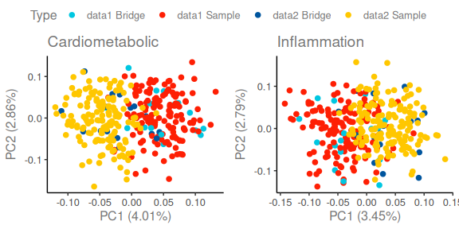

Figure 3. PCA plot of both datasets before bridging.

```r
if (requireNamespace(package = "ggpubr", quietly = TRUE)) {
  # PCA plot
  OlinkAnalyze::olink_pca_plot(
    df = npx_df_no_ctrl,
    color_g = "Type",
    byPanel = TRUE,
    check_log = check_log_npx_df_no_ctrl
  )
}
```

## Bridging between two data sets

We can use `olink_normalization_bridge()` function to bridge two datasets. The bridging procedure is to first calculate **the median of the paired NPX** **differences** per assay between the bridge samples as adjustment factor then use these adjustment factors to adjust NPX values between two datasets. In this process, one dataset is considered the reference dataset (`df1`) and its NPX values remain unaltered. The other dataset is considered the new dataset (`df2`) and is adjusted to the reference dataset based on the adjustment factors.

The output from `olink_normalization_bridge()` function is a NPX table with adjusted NPX value in the column `NPX`, as shown in Table 4. `olink_normalization_bridge()` is a wrapper for and supersedes `olink_normalization()` .

`olink_normalization_bridge()` creates a new column `Project` to distinguish between reference dataset from the other dataset. It is up to the user to define which dataset is the reference dataset and specify the names of the bridge samples. The resulting dataset will contain the reference dataset, which will be identical to the input reference data, with adjustment factors of 0, and the newly bridged dataset.

**NOTE:** The alternative quantification columns (for example: Quantified value, count, and Ct data) are not normalized.

```r
overlapping_samples_list <- list(
  "DF1" = overlapping_samples,
  "DF2" = overlapping_samples
)

# Perform bridging
npx_df_br <- OlinkAnalyze::olink_normalization_bridge(
  project_1_df = npx_data1_clean,
  project_2_df = npx_data2_clean,
  bridge_samples = overlapping_samples_list,
  project_1_name = "data1",
  project_2_name = "data2",
  project_ref_name = "data1",
  project_1_check_log = check_log_npx_data1_clean,
  project_2_check_log = check_log_npx_data2_clean
)

# generate check log on bridged data
check_log_npx_df_br <- OlinkAnalyze::check_npx(
  df = npx_df_br
)
```

Table 4. First 10 rows of the normalized dataset after bridging.

| SampleID | Index | OlinkID | UniProt | Assay | MissingFreq | Panel_Version | PlateID | QC_Warning | LOD | NPX | Subject | Treatment | Site | Time | Project | Panel | Adj_factor |
| --- | --- | --- | --- | --- | --- | --- | --- | --- | --- | --- | --- | --- | --- | --- | --- | --- | --- |
| A1 | 1 | OID01216 | O00533 | CHL1 | 0 | v.1201 | Example_Data_1_CAM.csv | Pass | 2.4 | 13.0 | ID1 | Untreated | Site_D | Baseline | data1 | Olink Cardiometabolic | 0 |
| A2 | 2 | OID01216 | O00533 | CHL1 | 0 | v.1201 | Example_Data_1_CAM.csv | Pass | 2.4 | 11.3 | ID1 | Untreated | Site_D | Week.6 | data1 | Olink Cardiometabolic | 0 |
| A3 | 3 | OID01216 | O00533 | CHL1 | 0 | v.1201 | Example_Data_1_CAM.csv | Pass | 2.4 | 25.5 | ID1 | Untreated | Site_D | Week.12 | data1 | Olink Cardiometabolic | 0 |
| A4 | 4 | OID01216 | O00533 | CHL1 | 0 | v.1201 | Example_Data_1_CAM.csv | Pass | 2.4 | 14.5 | ID2 | Untreated | Site_C | Baseline | data1 | Olink Cardiometabolic | 0 |
| A5 | 5 | OID01216 | O00533 | CHL1 | 0 | v.1201 | Example_Data_1_CAM.csv | Pass | 2.4 | 7.6 | ID2 | Untreated | Site_C | Week.6 | data1 | Olink Cardiometabolic | 0 |
| A6 | 6 | OID01216 | O00533 | CHL1 | 0 | v.1201 | Example_Data_1_CAM.csv | Pass | 2.4 | 6.3 | ID2 | Untreated | Site_C | Week.12 | data1 | Olink Cardiometabolic | 0 |
| A7 | 7 | OID01216 | O00533 | CHL1 | 0 | v.1201 | Example_Data_1_CAM.csv | Pass | 2.4 | 12.7 | ID3 | Untreated | Site_D | Baseline | data1 | Olink Cardiometabolic | 0 |
| A8 | 8 | OID01216 | O00533 | CHL1 | 0 | v.1201 | Example_Data_1_CAM.csv | Pass | 2.4 | 13.7 | ID3 | Untreated | Site_D | Week.6 | data1 | Olink Cardiometabolic | 0 |
| CONTROL_SAMPLE_AS 1_CAM1 | 9 | OID01216 | O00533 | CHL1 | 0 | v.1201 | Example_Data_1_CAM.csv | Pass | 2.4 | 16.2 | NA | NA | NA | NA | data1 | Olink Cardiometabolic | 0 |
| A9 | 10 | OID01216 | O00533 | CHL1 | 0 | v.1201 | Example_Data_1_CAM.csv | Pass | 2.4 | 6.1 | ID3 | Untreated | Site_D | Week.12 | data1 | Olink Cardiometabolic | 0 |

## Perform bridging with non-matching sample names

`olink_normalization_bridge()` also supports data where the overlapping samples (bridge samples) are not named the same in both projects. In this case the `overlapping_samples_list` will contain 2 arrays of equal length where the index of each entry corresponds to the same sample. For example, if a sample has the `SampleID` `Sample_1_Aliquot_1` in the first batch and `Sample_1_Aliquot_2` in the second batch, then the `overlapping_samples_list` should be defined as follows.

```r
overlapping_samples_list <- list(
  "DF1" = c("A1", "A2", "A3", "Sample_1_Aliquot_1"),
  "DF2" = c("A1", "A2", "A3", "Sample_1_Aliquot_2")
)
```

## Bridging evaluation

First, check the NPX distribution in datasets after bridging, as shown in Figure 4. Figure 4 shows a larger overlap in projects than seen in Figure 2, as indicated by fewer areas of red and blue along the outside of the distribution.

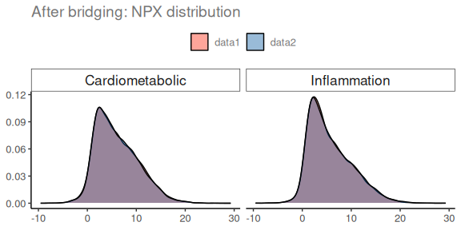

Figure 4. Density plot of NPX distribution in both datasets after bridging.

```r
# Filter out control samples to avoid skewing the distribution
# and affecting downstream PCA results.
npx_df_br_no_ctrl <- npx_df_br |>
  # Remove control samples
  dplyr::filter(
    stringr::str_detect(
      string = .data[["SampleID"]],
      pattern = "CONTROL_SAMPLE",
      negate = TRUE
    )
  ) |>
  # Mark bridge samples
  dplyr::mutate(
    Type = dplyr::if_else(
      .data[["SampleID"]] %in% .env[["overlapping_samples"]],
      paste(.data[["Project"]], "Bridge"),
      paste(.data[["Project"]], "Sample")
    )
  ) |>
  dplyr::mutate(
    SampleID = paste0(.data[["SampleID"]],
                      .data[["Project"]])
  )

# Update attached check log
npx_df_br_no_ctrl <- OlinkAnalyze::update_check_log(
  df = npx_df_br_no_ctrl
  )

# Plot NPX density after bridging
npx_df_br_no_ctrl |>
  dplyr::mutate(
    Panel = gsub(
      pattern = "Olink ",
      replacement = "", x = .data[["Panel"]]
    )
  ) |>
  ggplot2::ggplot(
    mapping = ggplot2::aes(
      x = .data[["NPX"]],
      fill = .data[["Project"]]
    )
  ) +
  ggplot2::geom_density(
    alpha = 0.4
  ) +
  ggplot2::facet_grid(
    cols = ggplot2::vars(.data[["Panel"]])
  ) +
  OlinkAnalyze::olink_fill_discrete(
    coloroption = c("red", "darkblue")
  ) +
  OlinkAnalyze::set_plot_theme() +
  ggplot2::ggtitle(
    label = "After bridging: NPX distribution"
  ) +
  ggplot2::theme(
    axis.title.x = ggplot2::element_blank(),
    axis.title.y = ggplot2::element_blank(),
    strip.text = ggplot2::element_text(size = 16L),
    legend.title = ggplot2::element_blank(),
    legend.position = "top"
  )
```

Then, summarize number of assays that have adjustment factors in certain ranges. High adjustment factors can result from variations between projects, such as panel versions or technical modifications. The cutoff of a deviating adjustment factor is subjective and depends on a variety of factors including the distribution of adjustment factors, as shown in Figure 5. While there are a few assays with adjustment factors between 2 and 4 and -2 and -4, the majority of the adjustment factors shown in Figure 5 occur between -2 and 2.

Such assays can be visualized individually with violin plots, as shown in Figure 6, and may warrant further investigation to confirm they are still comparable between projects. For example, if a violin plot exhibits a different range or truncated distribution, this may suggest that the assay is below LOD or at hook in one of the data sets. However, as long as the bridge samples are not at hook or below LOD, this should not impact the bridging quality. For projects with differing clinical phenotypes, it is more informative to look at the similarities between the bridge samples than the similarity between the datasets, as indicated by the overlaid black dots in Figure 6.

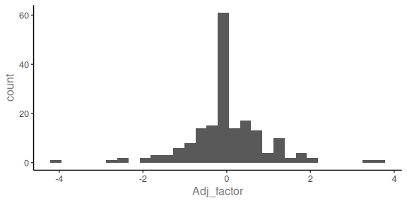

Figure 5. Histogram of adjustment factors in normalized data from dataset `npx_data2`.

The distribution of CHL1 between projects is visualized for demonstration purposes.

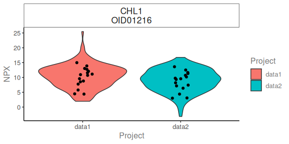

Figure 6. Violin plot of CHL1 in both datasets prior to bridging. Bridge samples are indicated by black points.

```r
# Bridge sample data
bridge_samples <- npx_df |>
  dplyr::filter(
    .data[["SampleID"]] %in% .env[["overlapping_samples"]]
  ) |>
  dplyr::filter(
    .data[["Assay"]] == "CHL1"
  ) |>
  dplyr::mutate(
    Assay_OID = paste(.data[["Assay"]], .data[["OlinkID"]], sep = "\n")
  )

# Generate violin plot for CHL1
npx_df_no_ctrl |>
  dplyr::filter(
    .data[["Assay"]] == "CHL1"
  ) |>
  dplyr::mutate(
    Assay_OID = paste(.data[["Assay"]], .data[["OlinkID"]], sep = "\n")
  ) |>
  ggplot2::ggplot(
    mapping = ggplot2::aes(
      x = .data[["Project"]],
      y = .data[["NPX"]]
    )
  ) +
  ggplot2::geom_violin(
    mapping = ggplot2::aes(
      fill = .data[["Project"]]
    )
  ) +
  ggplot2::geom_point(
    data = bridge_samples,
    position = ggplot2::position_jitter(
      width = 0.1
    )
  ) +
  ggplot2::theme(
    legend.position = "none"
  ) +
  OlinkAnalyze::set_plot_theme() +
  ggplot2::facet_wrap(
    facets = ggplot2::vars(.data[["Assay_OID"]]),
    nrow = 1L,
    ncol = 1L
  )
```

Another way to determine if bridging decreased variability between projects is to calculate the coefficient of variation (CV) of the control samples across both projects before and after bridging, as shown in Figure 7. The CV after normalization is expected to be smaller than the CV prior to normalization.

Note that the CV calculation formula differs between Olink qPCR and Olink NGS products. More information of CV calculation can be found in the [Olink FAQ](https://olink.com/knowledge/faq).

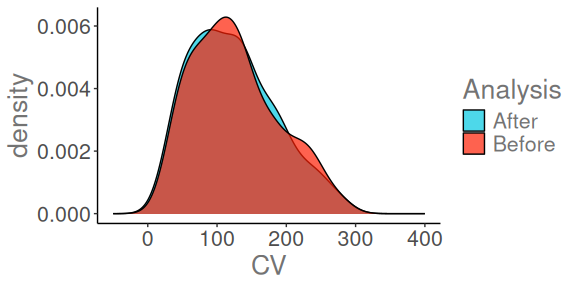

Figure 7. Density plot of inter-project CV before and after bridging.

```r
# Olink NGS products CV calculation formula
ngs_cv <- function(npx, na_rm = FALSE) {
  sqrt(exp((log(2) * sd(npx, na.rm = na_rm)) ^ 2) - 1) * 100
}

# Olink qPCR products CV calculation formula
qpcr_cv <- function(npx, na_rm = TRUE) {
  100 * sd(2 ^ npx) / mean(2 ^ npx)
}

tech <- "qPCR"

# Calculate CV for control samples across projects before bridging
cv_before <- npx_df |>
  dplyr::filter(
    stringr::str_detect(
      string = .data[["SampleID"]],
      pattern = "CONTROL*."
    )
  ) |>
  dplyr::filter(
    .data[["NPX"]] > .data[["LOD"]]
  ) |>
  dplyr::group_by(
    .data[["OlinkID"]]
  ) |>
  dplyr::mutate(
    CV = dplyr::if_else(
      .env[["tech"]] == "NGS",
      ngs_cv(npx = .data[["NPX"]]),
      qpcr_cv(npx = .data[["NPX"]])
    )
  ) |>
  dplyr::ungroup() |>
  dplyr::distinct(
    .data[["OlinkID"]], .data[["CV"]]
  )

# Calculate CV for control samples across projects after bridging
cv_after <- npx_df_br |>
  dplyr::filter(
    stringr::str_detect(
      string = .data[["SampleID"]],
      pattern = "CONTROL*."
    )
  ) |>
  dplyr::filter(
    .data[["NPX"]] > .data[["LOD"]]
  ) |>
  dplyr::group_by(
    .data[["OlinkID"]]
  ) |>
  dplyr::mutate(
    CV = dplyr::if_else(
      .env[["tech"]] == "NGS",
      ngs_cv(npx = .data[["NPX"]]),
      qpcr_cv(npx = .data[["NPX"]])
    )
  ) |>
  dplyr::ungroup() |>
  dplyr::distinct(
    .data[["OlinkID"]], .data[["CV"]]
  )

# Plot distribution of CV before and after bridging
cv_before |>
  dplyr::mutate(
    Analysis = "Before"
  ) |>
  dplyr::bind_rows(
    cv_after |>
       dplyr::mutate(
         Analysis = "After"
        )
  ) |>
  ggplot2::ggplot(
    mapping = ggplot2::aes(
      x = .data[["CV"]],
      fill = .data[["Analysis"]]
      )
    ) +
  ggplot2::geom_density(
    alpha = 0.7
    ) +
  OlinkAnalyze::set_plot_theme() +
  OlinkAnalyze::olink_fill_discrete() +
  ggplot2::theme(
    text = ggplot2::element_text(
      size = 20L
      )
  ) +
  ggplot2::xlim(-50L, 400L)
```

Finally, use PCA plot to check whether bridging has effect in correcting batch effects (Figure 8). In the example below, it is clear that before bridge samples from data 1 and 2 are divided into separate clusters due to the batch effects (Figure 3), but after bridging they are shown as one cluster in the PCA plot (Figure 8). Bridging has sufficiently removed the batch effects between two data sets.

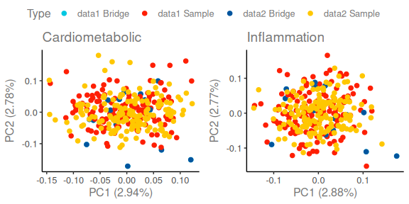

Figure 8. PCA plot of both datasets after bridging.

```r
if (requireNamespace(package = "ggpubr", quietly = TRUE)) {
  # PCA plot
  OlinkAnalyze::olink_pca_plot(
    df = npx_df_br_no_ctrl,
    color_g = "Type",
    byPanel = TRUE
  )
}
```

## Export Bridged data

Normalized data in long format can be exported using the `write.table()` function. Note that 2 columns are added during the bridging process, so to have the export format match the input format, the columns “Project” and “Adj_factor” need to be removed. To export exclusively the non-reference project, the `dplyr::filter()` function can be used.

```r
npx_df_br |>
  dplyr::filter(
    .data[["Project"]] == "data2"
  ) |>
  dplyr::select(
    -dplyr::all_of(
      c("Project", "Adj_factor")
    )
  ) |>
  write.table(
    file = "New_Normalized_NPX_data.csv",
    append = FALSE,
    quote = FALSE,
    sep = ";",
    eol = "\n",
    na = "",
    dec = ".",
    row.names = FALSE,
    col.names = TRUE
  )
```

## Contact Us

We are always happy to help. Email us with any questions:

- biostat@olink.com for statistical services and general stats questions
- support@olink.com for Olink lab product and technical support
- info@olink.com for more information

## Legal Disclaimer

© 2026 Olink Proteomics AB, part of Thermo Fisher Scientific.

Olink products and services are For Research Use Only. Not for use in diagnostic procedures.

All information in this document is subject to change without notice. This document is not intended to convey any warranties, representations and/or recommendations of any kind, unless such warranties, representations and/or recommendations are explicitly stated.

Olink assumes no liability arising from a prospective reader’s actions based on this document.

OLINK, NPX, PEA, PROXIMITY EXTENSION, INSIGHT and the Olink logotype are trademarks registered, or pending registration, by Olink Proteomics AB. All third-party trademarks are the property of their respective owners.

Olink products and assay methods are covered by several patents and patent applications [https://www.olink.com/patents/](https://olink.com/patents/).